# Data Science Capstone - Milestone Report

holliPista

2021 03 29

### Marco… Polo! - What is this about?

Here you can read my Milestone report for Data Science Capstone Project on Coursera.

In the following weeks I build a predictive model and a web application based on that: this model will try to predict the next word of any given word - that’s called text prediction. Till now I

### Getting the data

You can find the training dataset on the following [link](https://d396qusza40orc.cloudfront.net/dsscapstone/dataset/Coursera-SwiftKey.zip) but the code chunk below will download and unpack it if you do not have yet.

```r
url<-"https://d396qusza40orc.cloudfront.net/dsscapstone/dataset/Coursera-SwiftKey.zip"
if(!file.exists("Coursera-SwiftKey.zip")) {
  download.file(url,"Coursera-SwiftKey.zip","curl")} #download if not exist


if(file.exists("final")) {
  size_files <- list.files("final/en_US",full.names = T) %>%
    sapply(file.size) %>%
    sum()
}else{
  size_files=0
} #check if it's unpacked and unzip if necessary
if(size_files==0) {
  unzip("Coursera-SwiftKey.zip", files = NULL, list = FALSE, overwrite = TRUE,
        junkpaths = FALSE, exdir = ".", unzip = "internal", setTimes = FALSE)}

files <- list.files(path="final/en_US/", pattern="*.txt", full.names=TRUE,
                    recursive=FALSE) #get file list
```

Now we have to take a look on the data. It’s crucial in order to tell if we can use it as is or rather use a sample of it. The most important attribution is the file size as it refers to the memory demand but we also check the number of posts (ie. rows) and the gross total count of words (ie. tokens). Notice that I use binomial reading mode to eliminate line brake warnings and set encoding to utf-8 as a result of character encoding issue on my environment.

```r
con <- file("./final/en_US/en_US.blogs.txt", "rb", encoding="utf-8")
EnBlogs<- readLines(con, encoding = "UTF-8", skipNul = TRUE)
close(con)
EnBlogsStat <- c(stri_stats_general(EnBlogs)[1],  stri_stats_latex(EnBlogs)[4], file.info("./final/en_US/en_US.blogs.txt")$size/(2^20))

con <- file("./final/en_US/en_US.news.txt", "rb", encoding="utf-8")
EnNews<- readLines(con, encoding = "UTF-8", skipNul = TRUE)
close(con)
EnNewsStat <- c(stri_stats_general(EnNews)[1],  stri_stats_latex(EnNews)[4], file.info("./final/en_US/en_US.news.txt")$size/(2^20))

con <- file("./final/en_US/en_US.twitter.txt", "rb", encoding="utf-8")
EnTwitter<- readLines(con, encoding = "UTF-8", skipNul = TRUE)
close(con)
EnTwitterStat <- c(stri_stats_general(EnTwitter)[1],  stri_stats_latex(EnTwitter)[4], file.info("./final/en_US/en_US.twitter.txt")$size/(2^20))

EnTotalStat <- EnBlogsStat+EnNewsStat+EnTwitterStat
Stat<-as.data.frame(rbind(EnBlogsStat,EnNewsStat,EnTwitterStat,EnTotalStat))
colnames(Stat)[3] <- "Size (MB)"
rownames(Stat)<- c("Blogs","News","Twitter posts","Total")
print(Stat)
```

```
##                 Lines     Words Size (MB)
## Blogs          899288  37570839  200.4242
## News          1010242  34494539  196.2775
## Twitter posts 2360148  30451170  159.3641
## Total         4269678 102516548  556.0658
```

Wow! It’s a lot of data! We should have a sample of that if we want to reduce the run time to a considerable level. We have 4,269,678 rows (that number has stored in EnTotalStat variable). Let’s build a sample of 50,000 posts, which is about 1%, used binomial random choice.

```r
sample<-vector(mode="character")
#SourceFileName<-vector(mode="character")
n<-50000  #set sample size

for (SourceFile in files){
  con <- file(SourceFile, "rb", encoding="utf-8")
  open(con)

  line <- readLines(con, n=1, encoding="UTF-8", skipNul = TRUE)
  while(length(line) > 0) {
    line<-readLines(con, 1, encoding="UTF-8", skipNul = TRUE)
    random<-rbinom(1,1,n/EnTotalStat[1]) #define binomial random with n/N
    if(random==1){
      sample<-append(sample,line)
      #SourceFileName<-gsub(".txt","",str_split(SourceFile, "/", simplify = TRUE)[3])
      #With the row above you can make a vector to store the source file for each rows, supposed you defined        #SourceFileName as vector at the top of the code chunk.
    }
  }
  close(con)
}
```

### Cleaning the data and Exploratory Data Analysis

Now we have an almost ready to use data set, the only thing left is the data cleaning. I use tidytext package (and tidy tools) mainly for that task and also for data exploration. I do some exploratory analysis inserted into the cleaning process. The steps are basically:

- Remove numbers, punctuation, brackets (excepted apostrophe),
- Tokenization,
- Remove stop words (eg. “a”, “the”, “is”, “are”)
- Remove profanity (supposed that we don’t want to predict them:-)) ([source](https://www.cs.cmu.edu/~biglou/resources/))
- Show some basic statistics of the corpus based on that.

You can see I use tibble objects. Tibbles are data frames, but they tweak some older behaviours to make life a little easier. See more [here](https://tibble.tidyverse.org/).

#### Unigrams

```r
StopWords<-tibble(stop_words)
text_df <- tibble(line = 1:length(sample), text = sample)

unigram <- mutate(text_df, text = gsub(x = text,
                    pattern = "[0-9]+|(?!')[[:punct:]]|\\(.*\\)",
                    replacement = "", perl=TRUE)) %>%
  unnest_tokens(input = text, output = word) %>%
  anti_join(StopWords,by="word") %>%
  mutate(word=gsub("\\'","",word))

url<-"https://www.cs.cmu.edu/~biglou/resources/bad-words.txt"
if(!file.exists("bad-words.txt")) {download.file(url = url, destfile = "./bad-words.txt")}
con<- file("bad-words.txt", "rb")
profanity <- readLines(con)
close(con)

profanity <- tibble(profanity) %>%
  rename(word = profanity)
unigram<-anti_join(unigram,profanity,by="word")
```

The most frequent unigrams on a classic ggplot chart and also on a fancy [wordcloud2](https://www.r-graph-gallery.com/196-the-wordcloud2-library.html) cloud.

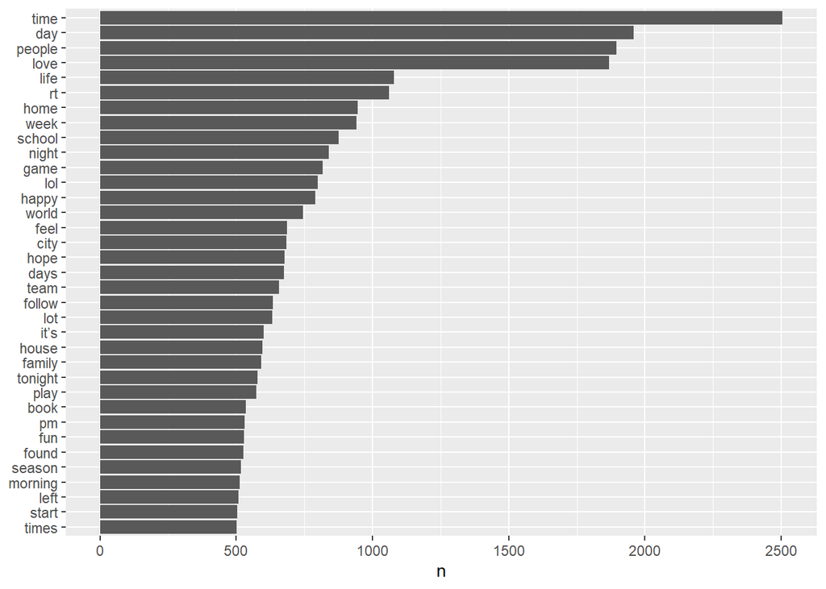

```r
unigram %>%
  count(word, sort = TRUE) %>%
  filter(n > 500) %>%
  mutate(word = reorder(word, n)) %>%
  ggplot(aes(n, word)) +
  geom_col() +
  labs(y = NULL)
```

```r
words <- unigram %>% count(word, sort=TRUE)
wordcloud2(data=words, size=1.6, color='random-dark')
```

[interactive chart not shown]

#### Bigrams

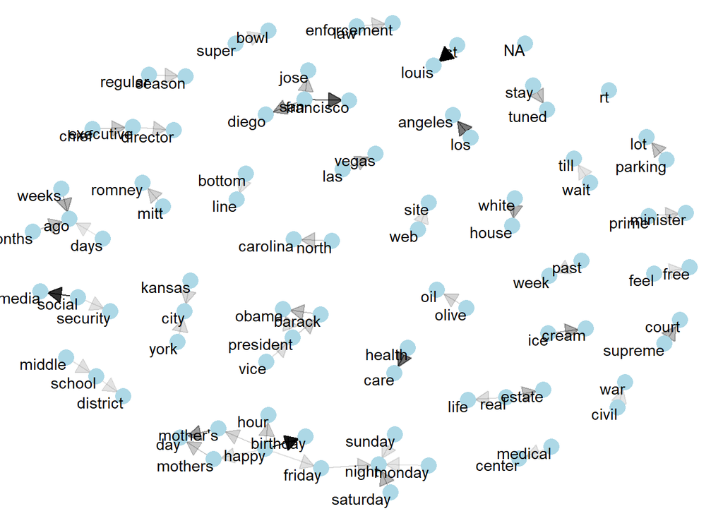

```r
bigram <- mutate(text_df, text = gsub(x = text,
                      pattern = "[0-9]+|(?!')[[:punct:]]|\\(.*\\)",
                      replacement = "", perl=TRUE)) %>%
  unnest_tokens(bigram, text, token = "ngrams", n = 2)

#bigram %>% count(bigram, sort = TRUE) #here I disregard to show simple frequency table of bigrams

bigrams_separated <- bigram %>%
  separate(bigram, c("word1", "word2"), sep = " ")

bigrams_filtered <- bigrams_separated %>%
  filter(!word1 %in% stop_words$word) %>%
  filter(!word2 %in% stop_words$word)

bigram_counts <- bigrams_filtered %>%
  count(word1, word2, sort = TRUE)

bigrams_united <- bigrams_filtered %>%
  unite(bigram, word1, word2, sep = " ")

bigram_graph <- bigram_counts %>%
  filter(n > 20) %>%
  graph_from_data_frame()

a <- grid::arrow(type = "closed", length = unit(.15, "inches"))

ggraph(bigram_graph, layout = "fr") +
  geom_edge_link(aes(edge_alpha = n), show.legend = FALSE,
                 arrow = a, end_cap = circle(.07, 'inches')) +
  geom_node_point(color = "lightblue", size = 5) +
  geom_node_text(aes(label = name), vjust = 1, hjust = 1) +
  theme_void()
```

### Next steps

Here I disregard to show trigrams due to the limitation of this paper, as it do not show any important information at that phase. (Although we can found the “happy mother’s day” token for example, which is clearly identifiable on the bigram chart above, on the left bottom part, but it’s just funny and not important.)

We have a solid base of further model development with this sample and tokenized data frames. However we should remove some further expressions (eg. “rt”). We also have to consider some optimization as we made the process more complicated than it needed.

After that I’ll check the unknown word’s problem (ie. words that not occurs in the sample).

If I finish all of that, you’ll meet my Shiny App soon! I count on you. Thank you.